# PR02 Streaming Services Data

Wednesday, May 10, 2023 @ 10:26 PM

## Setup

### Packages Used

```r
library(tidyverse)
library(skimr)
```

### Background of the Data

Two files containing data about thge content of streaming services were downloaded from Kaggle: [Disney+ Movies and TV Shows](https://www.kaggle.com/datasets/shivamb/disney-movies-and-tv-shows) and [TV shows on Netflix, Prime Video, Hulu and Disney+](https://www.kaggle.com/datasets/ruchi798/tv-shows-on-netflix-prime-video-hulu-and-disney). You can read about them there, including variable definitions, sources, when they were created, and other information. Read the two datasets from the `data_raw` folder and use `skim()` to explore their structures.

#### Disney+ Content Dataset

```r
disneydata <- read.csv("../data_raw/disneypluscontent_2021_11_21.csv")
```

#### Streaming TV Content Dataset

```r
streaming1 <- read.csv("../data_raw/streamingtvcontent_2021.csv")
```

## Analyses

### Clean, Tidy, and Save the Data

#### Dataset #1: Disney+ Data

The Disney+ dataset contains a variable that gives information about the `rating` for each program offering. Convert that variable into a factor that puts the ratings in (roughly) ascending order of age restriction/audience: `TV-Y`, `TV-Y7`, `TV-Y7-FV`, `TV-G`, `G`, `TV-PG`, `PG`, `PG-13`, `TV-14`. Delete the `show_id`, `director`, `cast`, and `description` variables. You should be able to do this all in one piped sequence.

```r
disney1 <- read.csv("../data_raw/disneypluscontent_2021_11_21.csv") %>%

  select(-c(show_id, director, cast, description))
disney1$rating <- factor(disney1$rating,
         levels = c("TV-Y", "TV-Y7", "TV-Y7-FV", "TV-G", "G", "TV-PG", "PG", "PG-13", "TV-14"))
```

#### Dataset #2: Streaming TV Data

Perform the following manipulations to tidy the streaming TV data for analysis. You should be able to do this all in one piped sequence.

- Pivot the `Netflix`, `Hulu`, `Prime Video`, and `Disney+` variables into two columns called `Service` (containing the name of the streaming service) and `YesNo` (containing the 0/1 values from the original columns).
- Filter the dataset to remove any row where `YesNo == 0` (i.e., a show is *not* on the service).
- Separate the `IMDb` variable to split each show’s actual rating from the maximum possible rating of `10`.
- Convert the show’s actual IMDB rating into a numerical variable and get rid of the column containing `10`.
- Separate the `Rotten Tomatoes` variable to split each show’s actual rating from the maximum possible rating of `100`.
- Convert the show’s actual Rotten Tomatoes rating into a numerical variable and get rid of the column containing `100`.

```r
streaming1 <- read.csv("../data_raw/streamingtvcontent_2021.csv") %>%

  pivot_longer(
    cols = c("Netflix", "Hulu", "Prime.Video", "Disney."),
    names_to = "Service",
    values_to = "YesNo") %>%
  filter(!(YesNo == 0)) %>%
  separate(col = IMDb,
           into = c("rawIMDb","tens"),
           sep = "/") %>%
  select(-tens) %>%
  separate(col = Rotten.Tomatoes,
           into = c("rawRT", "hundreds")) %>%
  select(-hundreds)

# Couldn't convert IMDb and Rotten Tomatoes columns to numeric as part of the piped sequence ("Error: object 'rawIMDb' not found") so they're changed in separate lines below

streaming1$IMDb <- as.numeric(streaming1$rawIMDb)
streaming1$RT <- as.numeric(streaming1$rawRT)
```

#### Save the Formatted Data Files

Save both data files in a single`.RData` file in the `data_tidy` folder.

```r
save(disney1, streaming1, file = "../data_tidy/streamingdata.RData")
```

### Analysis 1: Disney Content & Release Years

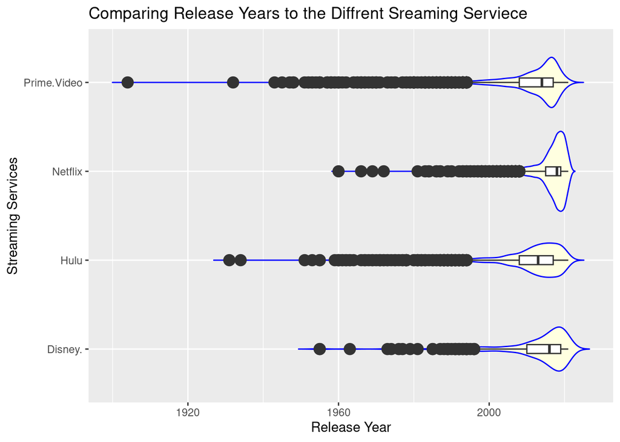

```r
ggplot(streaming1, aes(x = Year, y = Service)) +
  geom_violin(trim=FALSE, fill= "lightyellow", color="blue") +
  geom_boxplot(width = 0.1, outlier.size = 4) +
labs( title = "Comparing Release Years to the Diffrent Sreaming Serviece",
      x = "Release Year",
      y = "Streaming Services")
```

#### Release Years by Program Type—Plot #2

Create a histogram for `release_year` with `type` as a fill variable. Choose a reasonable number of bins or bin width. Re-scale the X axis so that tick marks appear at whole-decade intervals (e.g., 1980, 1990, 2000). Scale the Y axis to have reasonably spaced tick marks. Add vertical lines with annotations to indicate the debuts of the Disney Brothers Cartoon Studio (1923), the Disney Channel on TV (1983), and Disney+ streaming service (2019). Include an informative title and axis labels. Delete the title “type” from the legend. Add at least two other types of formatting to enhance the effectiveness and/or appearance of your plot (e.g., themes, colors, etc).

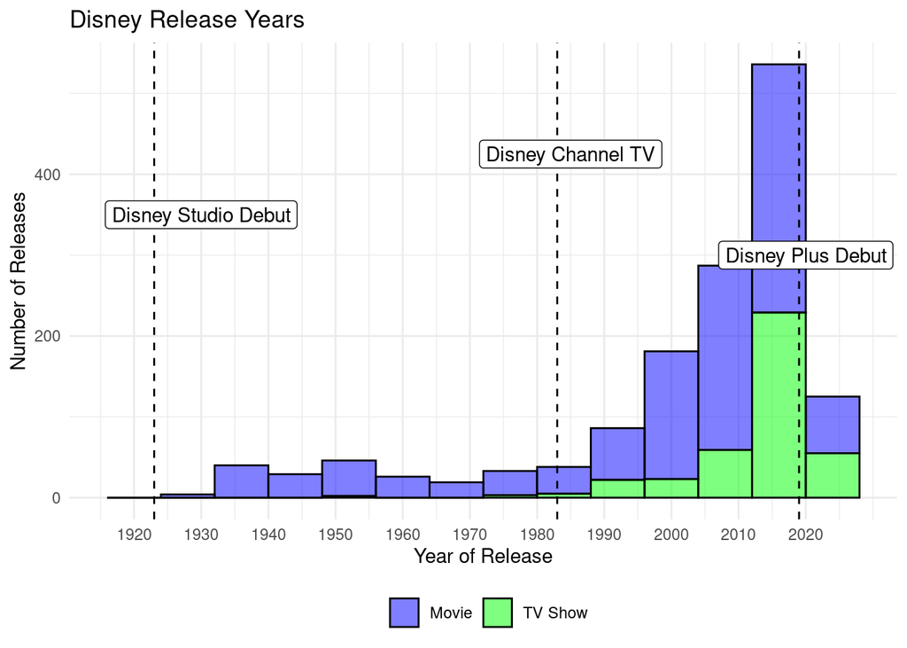

```r
ggplot(disney1, aes(x = release_year, fill = type)) +
  geom_histogram(binwidth = 8, colour = "black", alpha = 0.5) +
  geom_vline(xintercept = c(1923, 1983, 2019), linetype = "dashed") +
  scale_x_continuous(breaks = seq(1920, 2020, by = 10)) +
  scale_fill_manual(values = c("blue", "green")) +
  labs(title = "Disney Release Years", x = "Year of Release", y = "Number of Releases") +
theme_minimal() +
  theme(legend.position = "bottom", legend.title = element_blank()) +
annotate(geom = "label", x = 1930, y = 350, label = "Disney Studio Debut") +
annotate(geom = "label", x = 1985, y = 425, label = "Disney Channel TV") +
annotate(geom = "label", x = 2020, y = 300, label = "Disney Plus Debut")
```

### Analysis 3: Content on Different Services

**This analysis uses Dataset #2.**

#### Quantity of Content by Service

Create an appropriate barplot to show the number of TV shows offered by the four streaming services. Include an informative title and axis labels. Add at least two other types of formatting to enhance the effectiveness and/or appearance of your plot (e.g., themes, colors, etc).

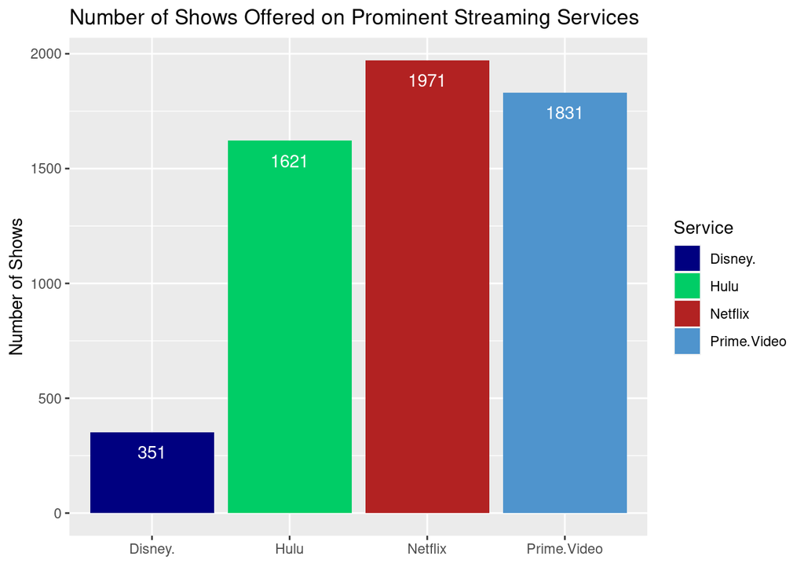

```r
ggplot(streaming1, aes(x = Service, fill = Service)) +
  geom_bar() +
  scale_fill_manual(values = c("navyblue", "springgreen3", "firebrick", "steelblue3")) +
  geom_text(aes(label = ..count..), stat = "count", vjust = 2, colour = "white") +
  labs(title = "Number of Shows Offered on Prominent Streaming Services",
       x = element_blank(),
       y = "Number of Shows")
```

#### Quality of Content by Service

Create an appropriate plot to compare either IMDB or Rotten Tomatoes ratings for content on the streaming services. Include an informative title and axis labels. Add at least two other types of formatting to enhance your plot (e.g., themes, colors, etc).

[figure not shown]

```r
ggplot(streaming1, aes(x = Service, y = rawRT)) +
  geom_boxplot( color = "black") +
  theme(panel.grid.major.x = element_blank()) +
  labs(title = "Rotten Tomatoes Ratings of Shows on Prominent Streaming Services",
       x = element_blank(),
       y = "Rotten Tomatoes ratings")
```

### Analysis 4: Choose Your Own Plot!

**This plot uses either dataset.**

Create one other plot of your choice using either dataset to explore a question of interest. It should not be too similar to any of the plots you made above. You are welcome to perform additional manipulations on the data, if needed. Add an appropriate title and axis labels, as well as any other necessary formatting to make your plot clear and effective.

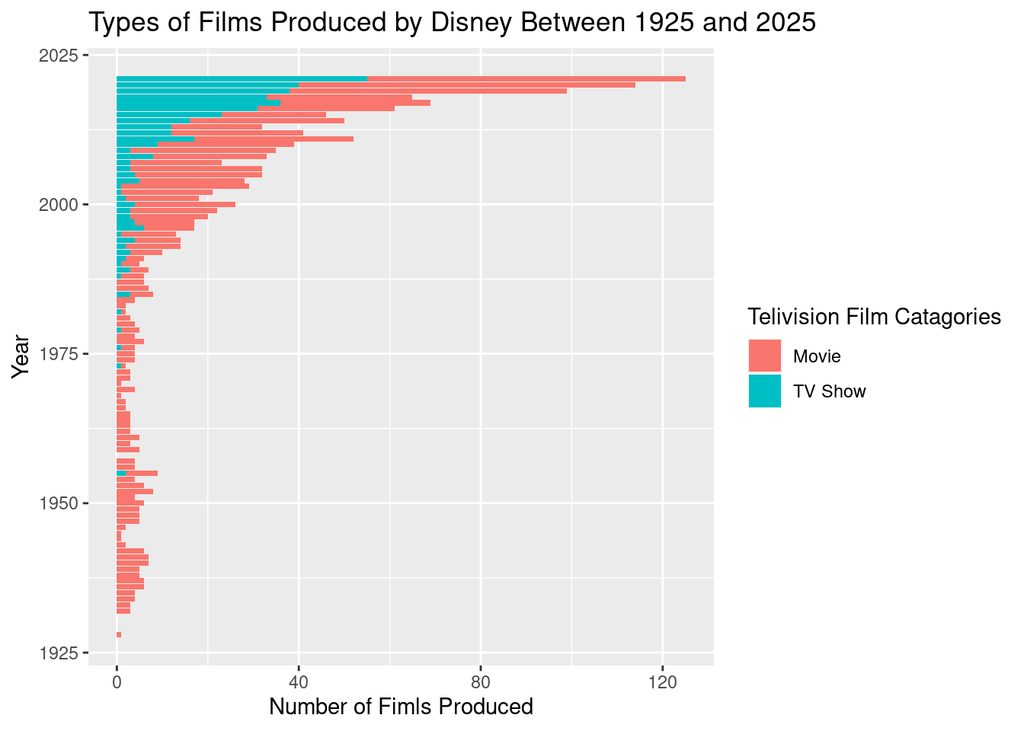

```r
ggplot(data = disney1, aes(x = release_year, fill = type)) +
  geom_bar() + coord_flip() +
   labs(
    title = "Types of Films Produced by Disney Between 1925 and 2025",
    x = "Year",
    y = "Number of Fimls Produced",
    fill = "Telivision Film Catagories")
```

## Questions

**Question 1:** Based on your plots, make five informational statements or comparisons regarding the Disney+ streaming service.

**Question 2:** What other data would you like to have, or which existing variables would you like to see transformed, if you were going to do further explorations or visualizations? Give at least two examples.

**Question 3:** Explain the rationale behind the choices you made with regard to plot type, formatting, and so on, when you created Analysis 4. What motivated your decisions with regard to this plot?